# Your Digest for Wednesday, Apr 03, 2024 11:59 PM

> [!TIP] Summary:  
> Multiple causes but commonest is drug induced.  
> Fever, rash, eosinophilia  
> No proteinuria  
> White cells casts  
> Managed with cessation of drug +/- corticosteroids
- Characterized by inflammatory infiltrate *in the renal interstitium*.
- **Causes**:
  - antibiotics (and other drugs), (**80%**)
  - autoimmune disease like **sarcoidosis**,
  - infections and
  - **TINU** (tubulerinterstitial nephritis with uveitis) syndrome.
- **Drugs**:
  - **NSAIDS** (including COX2 selective ones), *cephalosporins*, *PPIs* and many other antibiotics.[[General Medicine 4#Q 5 Adverse effects of PPI use.]]
- **Infections**;
  - legionella, leptospira, CMV and streptococcus.
- **Autoimmune associations:**
  - Sarcoidosis, Granulomatosis with polyangitis, SLE, Sjogrens
  - Triad of **fever**, **rash** and **eosinphilia** and non *specific symptoms of AKI.*
    - Rash is usually maculopapular or morbiliform. Most commonly seen in drug induced TIN.

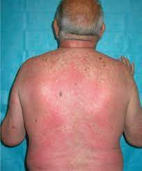

    - Can present with **proteinuria** if the disease is **NSAID** induced.
    - (nephrotic syndrome in AIN is unique to NSAID induced AIN).
- **Investigation** : Urine *white cell casts*, **eosinophiluria** (but this is not sensitive or specific).
- *Definitive diagnosis* requires **renal biopsy**.

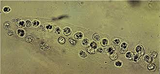

1. Bullous pemphigoid
2. pemphigus
3. **dermatitis herpetiformis**
4. **linear IgA**

> [!TIP] Mnemonic
> - Pemphigus and pemphigoid have G in their name: => IgG based.
> - Derm*a*titis herpetiformis and IgA have A in their name.
> - Pemphig*u*s => M*u*cosa
> - *O* for "Oh my god it itches!"

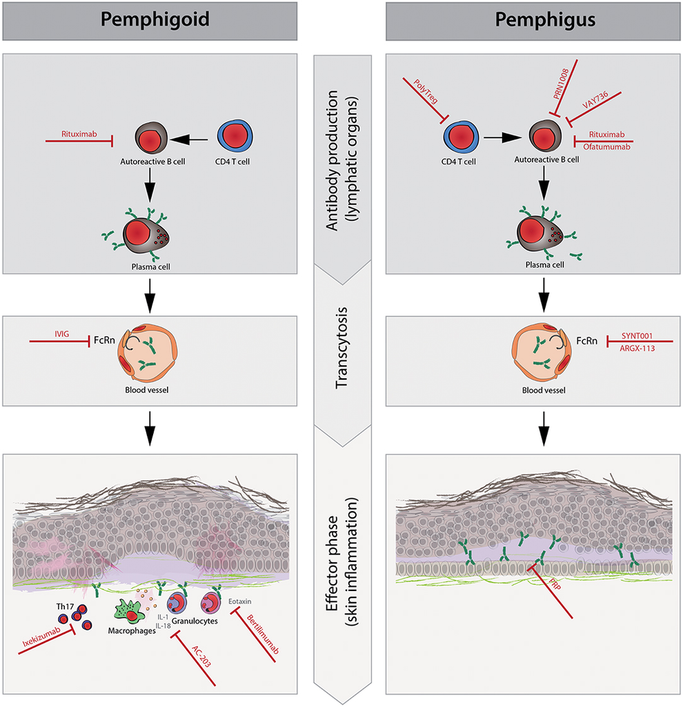

[Source](https://www.frontiersin.org/journals/immunology/articles/10.3389/fimmu.2019.00978/full)

[output not shown]

### Variations of pemphigus

1. Pemphigus vulgaris
2. Pemphigus foliaceus
3. IgA pemphigus
4. Paraneoplastic pemphigus

> [!TIP] Mnemonics :  
> Foliaceus - leaves -> leaves are above on tress -> bullae are subcorneal  
> Vulgaris -> the V points downwards -> suprabasal bullae

| PV | PF | IgAP | PNP |
| --- | --- | --- | --- |
| Mucosal or (Mucosal + cutaneous) | Cutaneous only. No oral lesions | Grouped vesicles or pustules and erythematous plaques with crusts | Extensive, intractable stomatitis and variable cutaneous findings with multiform exanthems. *Stomatitis is the commonest presentation* |
| Suprabasal acantholytic blisters | Subcorneal acantholytic bliters | subcorneal or intraepidermal acantholytic blisters |  |
| IgG antibodies against desmoglein 3 or both desmoglein 1 and desmoglein 3 | Desmoglein 1 |  | Associated with lymphoproliferative disorders:*non-Hodgkin lymphoma, chronic lymphocytic leukemia*, and Castleman's disease. |

- Rare, ⭐**life threatening**
- ⭐Antibodies against desmosomal cadherin found between epidermal cells. -> **intraepidermal blister** in skin and mucous membranes -> **erosions**
- ⭐**Oral lesions are common** (70%) - can precede skin lesions
- ⭐Pemphigus: Painful, *Intraepidermal*, *flaccid*, fragile blisters and itchy erosions.
- ⭐*Nikolsky sign +ve* <- rubbing normal skin causes sloughing.
- ⭐Usually occurs in adulthood.
- ⭐Recognised **triggers**: **ACEi**, rifampicin and penicillamine.
- ⭐Can have **paraneoplastic association** with non-hodgkin's lymphoma or chronic lymphocytic leukemia.
> - Lateral pressure applied to the border of a blister causes displacement of the epidermis and *extension of the blister*.
> - There is weakening of the assoociation *between corneal and granular layers* because of breakdown of **desmosomes**.
> - **Apparently normal skin** between the obvious blistering lesions **is also affected**.

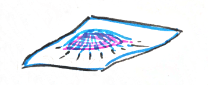

- Occurs *over 60 years of age*.
- IgG autoantibodies that target basement membrane cell -> dermo-epidermal junction breakdown -> **subepidermal split**
- *Tense* blisters
- *Steroid* and steroid sparing drugs for treatment.
- *No scarring*
- Course: acute or insidious episodes which remit.
- **Severe** pruritus.[Source](https://dermnetnz.org/topics/bullous-pemphigoid)
- Treatment can be stopped after few years but disease *often recurs*.
- Can involve *mucous membranes (20%)*.
- Can be triggered by vaccination (in children) and drugs (*NSAIDS*, *ACEi*, *frusemide*)
- *Pemphigoid gestationalis* is rare and occurs in the latter half of #pregnancy (T2 and T3) and post partum.

## Cerebral salt wasting

> [!TIP] SIADH lab picture but with **hypovolemia**.

| Arterial thrombi | Venous thrombi |
| --- | --- |
| High sheer stress environment | Low sheer stress environment |
| White thrombi (composed of platelet and fibrin) | Red thrombi (red cells and fibrin) |
| Main factors: turbulence + endothelial dysfunction | Stasis |
| Grow retrograde | Grow anterograde (all thrombi grow 'towards the heart' |
| *Lines of Zahn clearly visible* (plt + fibrin layer alternating with RBC layers) | *Lines of Zahn present but less distinct* (These are absent in post mortem clots |
|  | Are firm (unlike gelatinous post mortem thrombi) |
|  | Focally attached to vessel wall unlike PM thrombi |

- Distal - confined to calf veins
- Proximal - extending **into popliteal vein**; **larger and more like to embolize**
- Unusual site DVT: not originating in the deep veins of the leg.
- Unprovoked DVT => VTE where *no identifiable* **provoking event** or **risk factor** is evident
- Provoked DVT => VTE caused by a known event or risk factor (eg, **surgery**, *hospital admission*, *estrogen*)
- Parenteral therapy stopped once **INR >= 2.0**
- Target INR is between **2 - 3**
- Edoxaban and dabigatran - preceded by parenteral therapy for 5 days followed by *a switch* to [[General Medicine 4#DOACs|DOACs]]. *i.e : no overlap* , unlike with warfarin.
- Apixaban and rivaroxaban - *no parenteral therapy required*. But given for a higher dose for 7 to 21 days respectively.
- Stopping anticoagulation before 3 months duration -> higher risk of recurrence. (5% within the next year)
- **RBBB**
- **Right ventricular strain pattern** (*T⬇ in V1-V4 and inferior leads*)
- *R wave* - Dominant R way in V one
- *Rotation* - clock wise rotation - Shift of R/S transition point towards V6
- *Right atrial enlargement*